# Modelos para compilar

Irene Extremera Serrano

10/12/2020

```r
library(sp) #Tabajar con objetos de tipo espacial
library(rgdal) #Para que funcione sdmpredictors
library(carData)
library(car)
library(nlme)
library(gstat)
library(sf)
library(spData)
library(spdep)
library(lattice)
library(survival)
library(Formula)
library(ggplot2)
library(Hmisc)
library(raster) #Para poder trabajar con objetos tipo raster
library(leaflet)
library(GGally)
library(maptools)
library(corrplot)
library(rgeos)
library(maptools) #Cargar mapas
library(dismo) #Para poder trabajar con bioclim
library(sdmpredictors) #Para descargarme las variables ambientales
library(PresenceAbsence)
library(rJava)
```

```r
# Descargo el mapa del mundo
data(wrld_simpl) #Cargo el mapa del mundo
```

```r
# Datos
data <- read.csv('Datos/Anchoas_Aqua.csv',TRUE,",")
data<- data[-1]
```

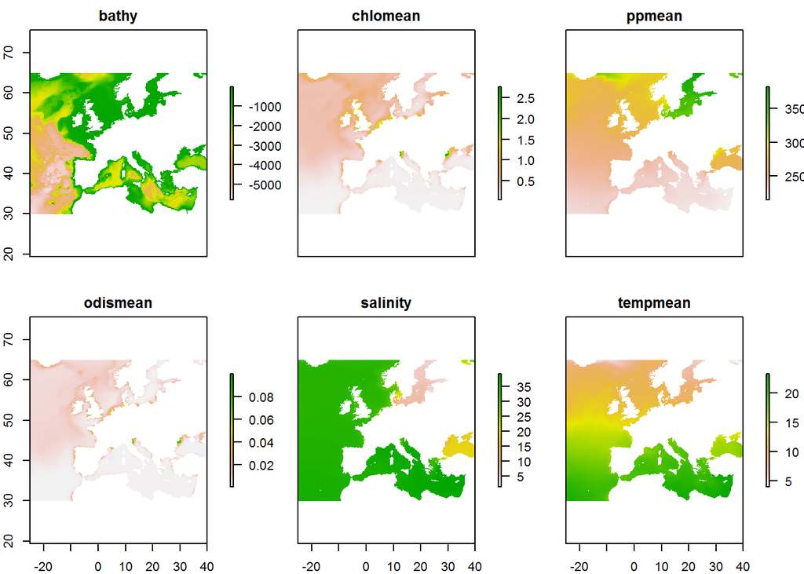

```r
# Predictores
files<-(list.files("C:/Users/Irene/Source/Repositorios/TFM-Irene-Extremera/Predictores", full.names=T, pattern=".tif"))#change directory
predictors <- stack(files)
names(predictors) <- c("bathy","chlomean","ppmean","odismean","salinity","tempmean")
plot(predictors)
```

```r
# Escalo los valores para que al hacer el análisis todas las variables tengan la misma escala
predictors2 <- scale(predictors)
round(apply(values(predictors2), 2, summary), 4)
```

```
                bathy    chlomean      ppmean    odismean    salinity    tempmean
  Min.        -2.3567     -1.0697     -1.3792     -0.8492     -4.1760     -2.4498
  1st Qu.     -0.8808     -0.9423     -0.8568     -0.7665      0.2015     -0.9504
  Median       0.1914      0.0210     -0.0826     -0.0125      0.2590      0.0206
  Mean         0.0000      0.0000      0.0000      0.0000      0.0000      0.0000
  3rd Qu.      1.0135      0.4712      0.5067      0.3634      0.3965      0.9835
  Max.         1.0801      9.8506      3.7348     17.1201      0.7440      1.8196
  NA's    150286.0000 150671.0000 153383.0000 153383.0000 153383.0000 153383.0000
```

```r
# Cargo la base de datos
sdmdata <- read.csv("Datos/sdmdata.csv")
```

##### — Descriptiva —

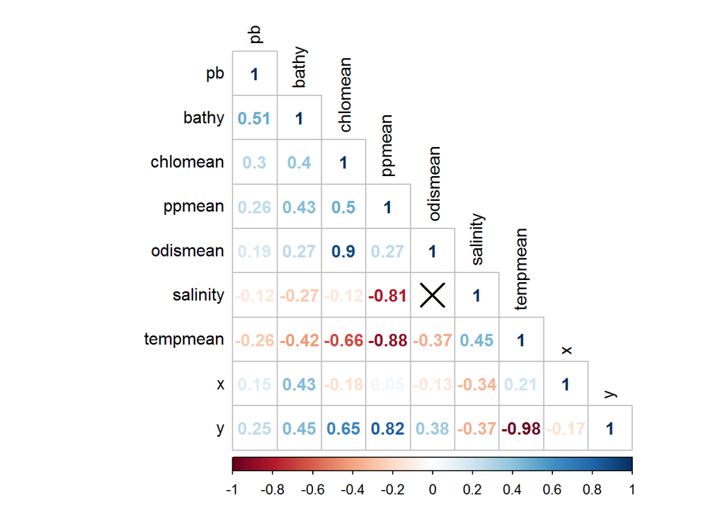

```r
# Miro la correlación entre variables para identificar qué variables o no incluir.
# La X muestra que no hay correlación significativa.
# La correlación se empieza a plantear el no introducirlaa partir de 0.7.
# Hago modelos con correlación y sin ella para ver cómo ajustan y ver cómo se explica.

matrix<-rcorr(as.matrix(sdmdata[,c(2:10)]), type = "pearson")

# ... : further arguments to pass to the native R cor.test function
cor.mtest <- function(mat, ...) {
  mat <- as.matrix(mat)
  n <- ncol(mat)
  p.mat<- matrix(NA, n, n)
  diag(p.mat) <- 0
  for (i in 1:(n - 1)) {
    for (j in (i + 1):n) {
      tmp <- cor.test(mat[, i], mat[, j], ...)
      p.mat[i, j] <- p.mat[j, i] <- tmp$p.value
    }
  }
  colnames(p.mat) <- rownames(p.mat) <- colnames(mat)
  p.mat
}

corrplot(matrix$r, type="lower", tl.col = "black",method="number",
         p.mat = matrix$P, sig.level = 0.05)
```

A si a primera vista diría que las variables mas indicadas para entrar en el modelo serían: bathy, odismean, salinity y tempmean. También podría valorarse cambiar chlomean por odismean.

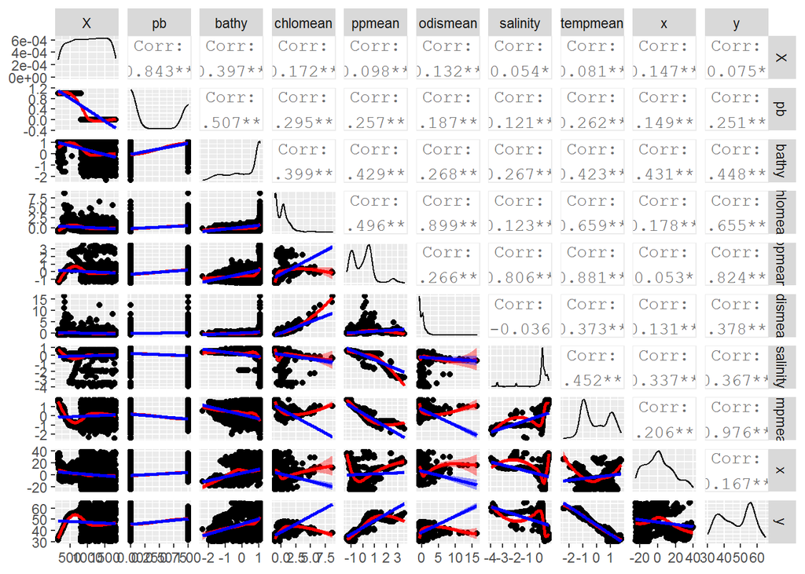

```r
# Paso 2
# Miro la relación entre la variable respuesta y las covariables con el fin de ver si tienen una relación lineal.
# Este análisis lo necesitaré posteriormente para considerar o no hacer un gam
my_fn <- function(data, mapping, ...){
  p <- ggplot(data = data, mapping = mapping) +
    geom_point() +
    geom_smooth(method=loess, fill="red", color="red", ...) +
    geom_smooth(method=lm, fill="blue", color="blue", ...)
  p
}

g = ggpairs(sdmdata, lower = list(continuous = my_fn))
g
```

En este pairs se aprecia lo siguiente: - No parece que niguna de las variables sea normal incluyendo la variable respuesta. Por lo que habrá que usar un GLMs o alternativas similares. - La variable respuesta pb (presencias y ausencias) se distribuye como una binomial.

```r
# Compruebo si hay o no multicolinealidad entre variables
# El objetivo es quedarse con un conjunto de variables con un VIF menor a 5 y 3.

source("HighstatLib.r") #Función ya hecha
corvif(sdmdata[,c(1:9)])
```

```
  Correlations of the variables

                     X         pb      bathy   chlomean      ppmean    odismean
  X         1.00000000 -0.8430369 -0.3968265 -0.1722215 -0.09840268 -0.13170390
  pb       -0.84303692  1.0000000  0.5074011  0.2950214  0.25737607  0.18655139
  bathy    -0.39682648  0.5074011  1.0000000  0.3985685  0.42923781  0.26757727
  chlomean -0.17222147  0.2950214  0.3985685  1.0000000  0.49637649  0.89944883
  ppmean   -0.09840268  0.2573761  0.4292378  0.4963765  1.00000000  0.26632537
  odismean -0.13170390  0.1865514  0.2675773  0.8994488  0.26632537  1.00000000
  salinity  0.05385434 -0.1210521 -0.2667481 -0.1225304 -0.80574446 -0.03631154
  tempmean  0.08138903 -0.2618325 -0.4229368 -0.6586650 -0.88063774 -0.37298487
  x        -0.14701333  0.1493097  0.4313795 -0.1781536  0.05278513 -0.13088709
              salinity    tempmean           x
  X         0.05385434  0.08138903 -0.14701333
  pb       -0.12105212 -0.26183252  0.14930971
  bathy    -0.26674812 -0.42293682  0.43137946
  chlomean -0.12253038 -0.65866504 -0.17815359
  ppmean   -0.80574446 -0.88063774  0.05278513
  odismean -0.03631154 -0.37298487 -0.13088709
  salinity  1.00000000  0.45219756 -0.33720648
  tempmean  0.45219756  1.00000000  0.20602030
  x        -0.33720648  0.20602030  1.00000000


  Variance inflation factors

                GVIF
  X         3.790881
  pb        4.380233
  bathy     2.450753
  chlomean 17.324478
  ppmean   67.461435
  odismean 10.642504
  salinity 19.478184
  tempmean 33.459824
  x         2.309838
```

# BIOCLIM

```r
# Hago el modelo de BIOCLIM
bc.model <- bioclim(x = predictors2, p = data)
```

```r
# FUNCIÓN DEFINITIVA DEFINITIVÍSIMA MILENARIA XTREM
# Esta función sirve para hacer una cross validation y obtener así los distintos índices que me interesan

fddmx <- function(coordenadas, predictores,background){

      group <- kfold(coordenadas, 5)

      pres_train <- coordenadas[group != 1, ] #Las que no sean 1
      pres_test <- coordenadas[group == 1, ] #Las que sean 1

      bc <- bioclim(predictores, pres_train)

      group <- kfold(background, 5) #Hago 5 grupos de esos puntos
      backg_train <- background[group != 1, ]
      backg_test <- background[group == 1, ]

      eval.modesta <- evaluate(pres_test, backg_test, bc, predictores)

      auc_bc.model <- eval.modesta@auc #auc

      cor_bc.model <- eval.modesta@cor #cor

      kappa_bc.model <- mean(eval.modesta@kappa) #Kappa

      sensibility_bc.model <- mean(eval.modesta@TPR/(eval.modesta@TPR+eval.modesta@FNR)) #Sensibilidad

      specificity_bc.modelo <- mean(eval.modesta@TNR/(eval.modesta@FPR+eval.modesta@TNR)) #Especificidad

      TSSbc.model <- mean(eval.modesta@TPR+eval.modesta@TNR-1) #TSS

      return(c(auc_bc.model,cor_bc.model,kappa_bc.model,sensibility_bc.model,specificity_bc.modelo,TSSbc.model))
}
```

```r
# Necesito este objeto con el que he creado la base de datos sdmdata.Son coordenadas aleatorias en las cuales puede o no haber presencia de la especie. La semilla es la misma.
set.seed(141592)
backgr <- randomPoints(predictors2, 1000)

# Hago una matriz para guardar los valores de los coeficientes de las diez iteraciones que me devuelva la función
cosites_bc.model <- matrix(ncol=6,nrow=10)

# Genereo un bucle for de 10 iteraciones que me devuelva 10 valores diferentes de los 6 coeficientes.
for (i in 1:10) { cosites_bc.model[i,] <- fddmx(data,predictors2,backgr)}

# Le doy nombre a las columnas para saber qué coeficientes hay dentro
colnames(cosites_bc.model) <- c('AUC','COR','Kappa','Sensitivity','Specificity','TSS')
```

```r
# Hago la media por columnas que es lo que me interesa y lo guardo
coef_bc.model <- apply(cosites_bc.model, 2, mean)
write.csv(coef_bc.model,'BIOCLIM/coeficientes_BIOCLIM.csv')
coef_bc.model
```

```
          AUC         COR       Kappa Sensitivity Specificity         TSS
    0.7733272   0.4048734   0.2597275   0.4464600   0.8091695   0.2556295
```

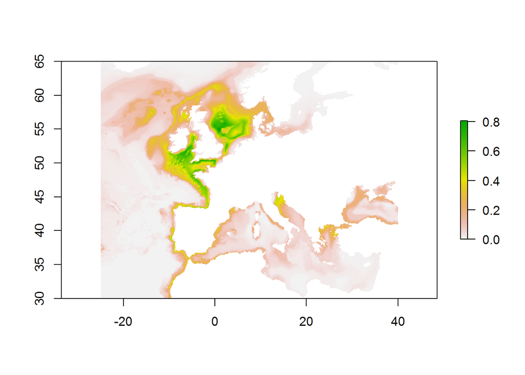

```r
# Predictiva de presencias
ext<-extent(-25,40,30,65) #Extensión de terreno (es la misma que usé para recortar los predictores)

predict.presence.bc.bioclim <- predict(object = bc.model,
                                   x = predictors2,
                                   ext = ext)

# La pinto
plot(predict.presence.bc.bioclim)
```

```r
# La guardo
saveRDS(predict.presence.bc.bioclim, "BIOCLIM/Predicciones_BIOCLIM.ascii")
```

En el mapa predictivo se puede ver que en el Mar del Norte y en la parte de costa Oeste de Gran Bretaña y Francia hay una probabilidad de presencia de hasta el 0.8. Este valor va disminuyendo progresivamente a medida que se aleja de la zona. Por otro lado, en la costa de España, Norte de Italia, sobre todo en la noreste, y costa africana cercana a la península ibérica la probabilidad de presencia es de 0.4-0.2.

# MAXENT

```r
# Construyo el modelo
maxent_model <- maxent(predictors2, data,backgr)
```

```
  This is MaxEnt version 3.3.3k
```

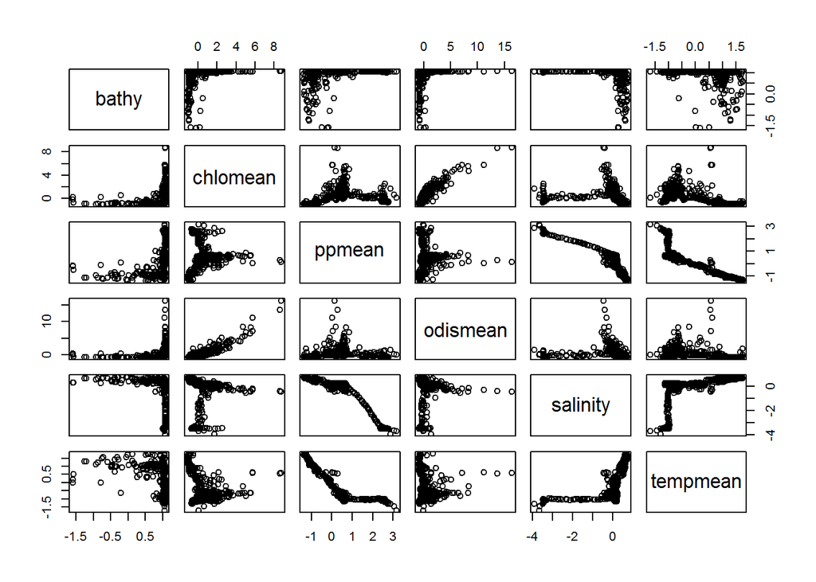

```r
plot(maxent_model@presence)
```

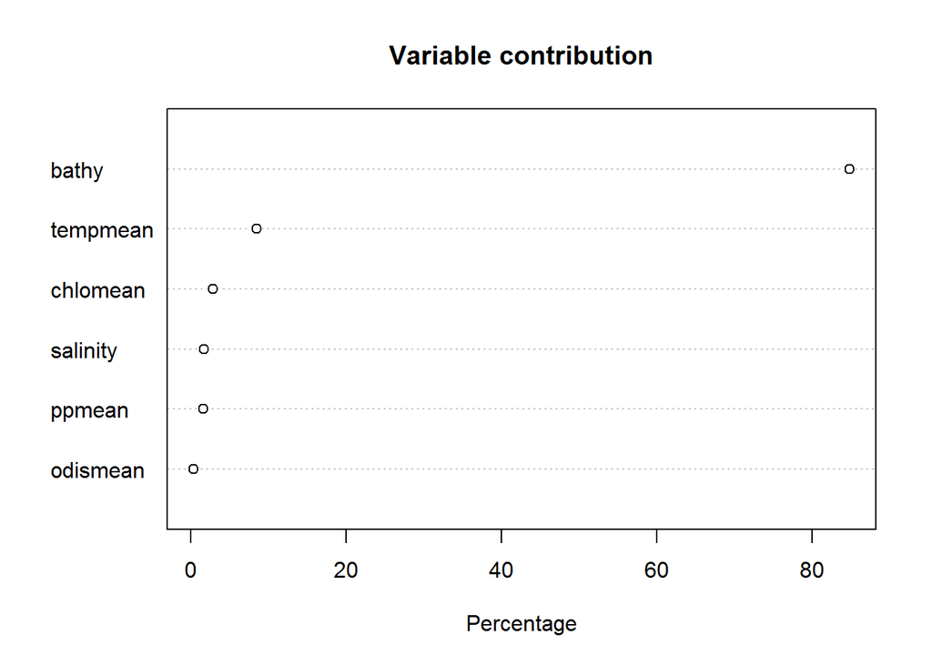

```r
plot(maxent_model)
```

Lo que entiendo aquí es que se está midiendo el porcentaje de cada variable en cuando a cómo es de importante a la hora de ajustar el modelo. Según muestra la gráfica las variables mas importantes son la batimetría y la temperatura media.

```r
fddmx2 <- function(coordenadas, predictores,background){

      group <- kfold(coordenadas, 5)

      pres_train <- coordenadas[group != 1, ] #Las que no sean 1
      pres_test <- coordenadas[group == 1, ] #Las que sean 1

      me_m<- maxent(predictors2, pres_train,background)

      group <- kfold(background, 5) #Hago 5 grupos de esos puntos
      backg_train <- background[group != 1, ]
      backg_test <- background[group == 1, ]

      eval.modesta <- evaluate(pres_test, backg_test, me_m, predictores)

      auc_bc.model <- eval.modesta@auc #auc

      cor_bc.model <- eval.modesta@cor #cor

      kappa_bc.model <- mean(eval.modesta@kappa) #Kappa

      sensibility_bc.model <- mean(eval.modesta@TPR/(eval.modesta@TPR+eval.modesta@FNR)) #Sensibilidad

      specificity_bc.modelo <- mean(eval.modesta@TNR/(eval.modesta@FPR+eval.modesta@TNR)) #Especificidad

      TSSbc.model <- mean(eval.modesta@TPR+eval.modesta@TNR-1) #TSS

      return(c(auc_bc.model,cor_bc.model,kappa_bc.model,sensibility_bc.model,specificity_bc.modelo,TSSbc.model))
}

# Hago una matriz para guardar los valores de los coeficientes de las diez iteraciones que me devuelva la función
cosites_maxent_model <- matrix(ncol=6,nrow=10)

# Genereo un bucle for de 10 iteraciones que me devuelva 10 valores diferentes de los 6 coeficientes.
for (i in 1:10) { cosites_maxent_model[i,] <- fddmx2(data,predictors2,backgr)}
```

[output not shown]

```r
# Le doy nombre a las columnas para saber qué coeficientes hay dentro
colnames(cosites_maxent_model) <- c('AUC','COR','Kappa','Sensitivity','Specificity','TSS')

# Hago la media por columnas que es lo que me interesa y lo guardo
coef_bc.model <- apply(cosites_maxent_model, 2, mean)
# write.csv(coef_bc.model,'MAXENT/coeficientes_MAXENT.csv')
```

```r
# Predicciones de presencia
predict.presence.maxent_model <- dismo::predict(object = maxent_model,
                                   x = predictors2,
                                   ext = ext)
```

```
  This is MaxEnt version 3.3.3k
```

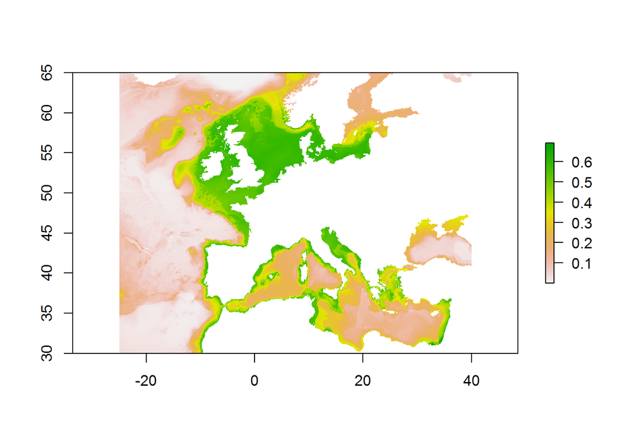

```r
plot(predict.presence.maxent_model)
```

```r
# Me guardo el modelo predictivo
# saveRDS(predict.presence.maxent_model, "MAXENT/Predicciones_MAXENT.ascii")
```